# Working with two gases measured simultaneously

In this example we will process the `raw_twogases` dataset which contains both CO<sub>2</sub> and CH<sub>4</sub> concentrations measured simultaneously. The aim is a single dataset of fluxes in which the CH<sub>4</sub> fluxes where also discarded when the CO<sub>2</sub> fluxes were discarded.

The concept is that we will treat the dataset twice, once for each gas, and then join them again in the end. Because `f_fluxid` is produced in chronological order based on start datetime in `field_record`, the fluxes measured at the same time have the same `f_fluxid`.

First we use `flux_match` to slice the raw concentration data and attribute a unique ID to each measurement.

```r
library(fluxible)
library(tidyverse)

conc_twogases <- flux_match(
  raw_conc = raw_twogases,
  field_record = twogases_record,
  f_datetime = datetime,
  start_col = start,
  measurement_length = 180,
  time_diff = 0
)
```

Then we fit a model to the raw data for each gas:

```r
slopes_twogases_co2 <- flux_fitting(
  conc_df = conc_twogases,
  f_conc = co2_conc,
  f_datetime = datetime,
  fit_type = "exp_zhao18",
  start_cut = 10
)

slopes_twogases_ch4 <- flux_fitting(
  conc_df = conc_twogases,
  f_conc = ch4_conc,
  f_datetime = datetime,
  fit_type = "exp_zhao18",
  start_cut = 10
)
```

Same with the quality, we do it once for each gas:

```r
flag_twogases_co2 <- flux_quality(
  slopes_df = slopes_twogases_co2,
  f_conc = co2_conc,
  force_discard = "8" # peak at the start that is probably an error
)
```

```
#>
#>  Total number of measurements: 12
#>
#>  ok   11      92 %
#>  force_discard    1   8 %
#>  discard      0   0 %
#>  zero     0   0 %
#>  start_error      0   0 %
#>  no_data      0   0 %
#>  force_ok     0   0 %
#>  force_zero   0   0 %
#>  force_lm     0   0 %
#>  no_slope     0   0 %
```

```r
flag_twogases_ch4 <- flux_quality(
  slopes_df = slopes_twogases_ch4,
  f_conc = ch4_conc,
  ambient_conc = 2000 # default is for CO2
)
```

```
#>
#>  Total number of measurements: 12
#>
#>  ok   9   75 %
#>  zero     3   25 %
#>  discard      0   0 %
#>  force_discard    0   0 %
#>  start_error      0   0 %
#>  no_data      0   0 %
#>  force_ok     0   0 %
#>  force_zero   0   0 %
#>  force_lm     0   0 %
#>  no_slope     0   0 %
```

We check the fits with `flux_plot`:

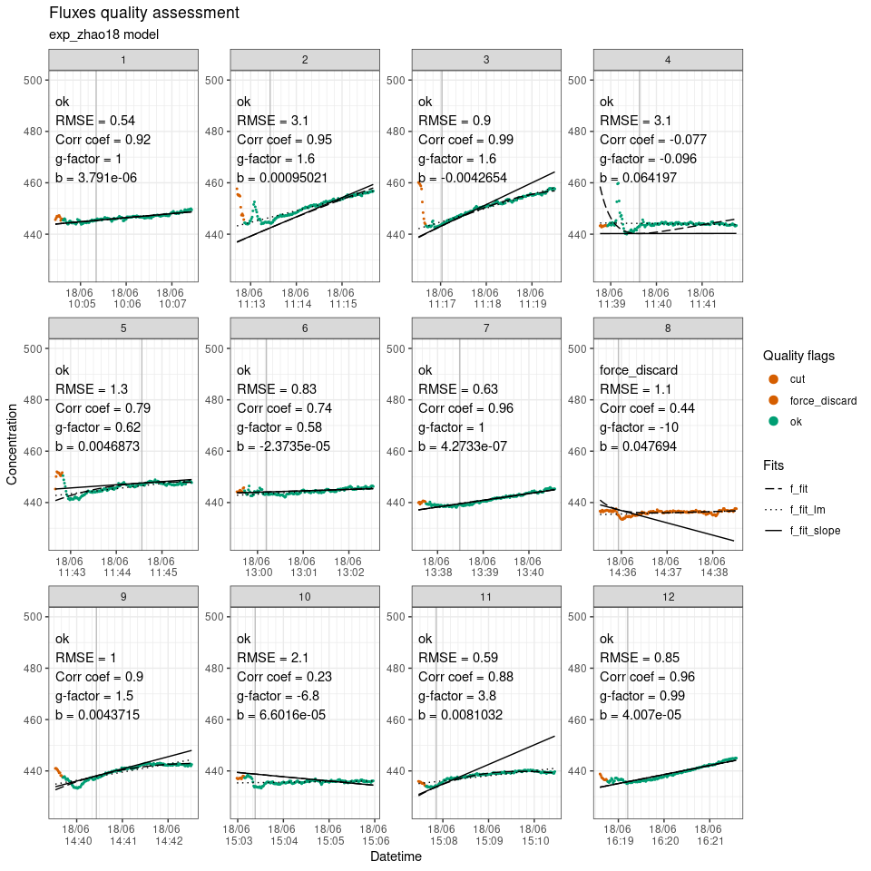

CO<sub>2</sub> measurements with quality flags.

```r
flag_twogases_co2 |>
  flux_plot(
    f_conc = co2_conc,
    f_datetime = datetime,
    f_ylim_upper = 500,
    f_ylim_lower = 425,
    y_text_position = 460
  )
```

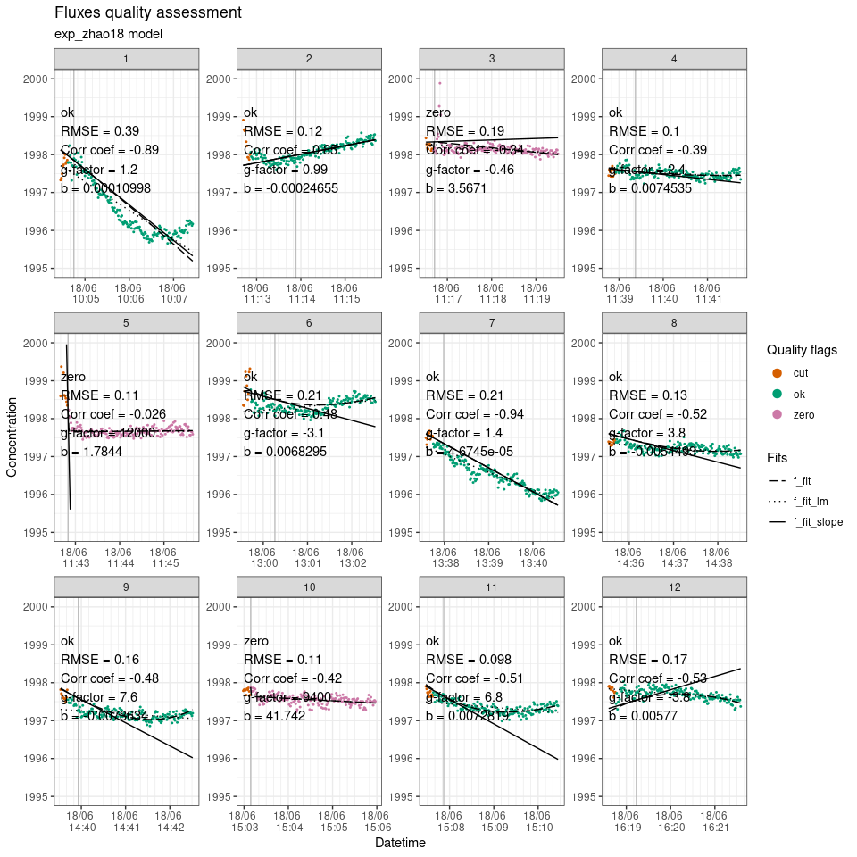

CH<sub>4</sub> measurements with quality flags.

```r
flag_twogases_ch4 |>
  flux_plot(
    f_conc = ch4_conc,
    f_datetime = datetime,
    f_ylim_upper = 2000,
    f_ylim_lower = 1995,
    y_text_position = 1997
  )
```

After calculating the fluxes, we need to rename the `f_flux` column to avoid confusion when joining the datasets:

```r
fluxes_twogases_co2 <- flux_calc(
  slopes_df = flag_twogases_co2,
  slope_col = f_slope_corr,
  f_datetime = datetime,
  temp_air_col = temp_air,
  conc_unit = "ppm",
  flux_unit = "mmol/m2/h",
  setup_volume = 6.31,
  atm_pressure = 1,
  plot_area = 0.31,
  # we want to use the quality flags of CO2 to eventally discard CH4 fluxes
  cols_keep = "f_quality_flag"
) |>
  rename( # to avoid any confusion, we rename the flux column
    flux_co2 = "f_flux"
  ) |> # and we remove the slope one
  select(-f_slope_corr)

fluxes_twogases_ch4 <- flux_calc(
  slopes_df = flag_twogases_ch4,
  slope_col = f_slope_corr,
  f_datetime = datetime,
  temp_air_col = temp_air,
  conc_unit = "ppb", # ch4 is measured in ppb
  flux_unit = "umol/m2/h", # we want a flux in umol/m2/h
  setup_volume = 6.31,
  atm_pressure = 1,
  plot_area = 0.31
) |>
  rename( # to avoid any confusion, we rename the flux column
    flux_ch4 = "f_flux"
  ) |> # and we remove the slope one
  select(-f_slope_corr)
```

Then we can join the datasets. If the final dataset ends up being longer, it probably means that some values in columns that should be equal (`f_temp_air_ave` for example) are in fact not equal, which leads to additional rows when joining the dataframes.

```r
fluxes_twogases <- left_join(
  fluxes_twogases_co2,
  fluxes_twogases_ch4,
  by = c(
    # if that does not work, then it means that we did
    # something different for one of the gases
    "f_fluxid",
    "f_temp_air_ave",
    "datetime",
    "f_model"
  )
) |>
  mutate( # we discard the CH4 fluxes based on CO2 fluxes quality flags
    flux_ch4 = case_when(
      f_quality_flag %in% c("discard", "force_discard") ~ NA,
      .default = flux_ch4
    )
  )
```

Structure of `fluxes_twogases`:

```
#> tibble [12 × 7] (S3: tbl_df/tbl/data.frame)
#>  $ f_quality_flag: chr [1:12] "ok" "ok" "ok" "ok" ...
#>  $ f_fluxid      : Factor w/ 12 levels "1","2","3","4",..: 1 2 3 4 5..
#>  $ f_temp_air_ave: num [1:12] 13.4 16.5 17.1 14.4 15 ...
#>  $ datetime      : POSIXct[1:12], format: "2024-06-18 10:04:37" ...
#>  $ flux_co2      : num [1:12] 0.08292 0.38505 0.43518 0.00108 0.0637..
#>  $ f_model       : chr [1:12] "exp_zhao18" "exp_zhao18" "exp_zhao18"..
#>  $ flux_ch4      : num [1:12] -0.04873 0.01165 0 -0.00649 0 ...
```

In this example we calculated the fluxes for two gases measured simultaneously by repeating the process for each gas, and in the end we joined them and applied a rule that discarded the fluxes of one gas based on the quality flags of the other. It is of course totally possible to apply other rules, or to just keep the fluxes as provided by `fluxible`.